# Introduction to single-cell RNA-seq analysis

Cluster marker genes - Cell type labelling

# 1 Load data

```r
library(scater)
library(scran)
library(tidyverse)
library(patchwork)
```

Re-run `scoreMarkers` on the clustered data.

```r
sce <- readRDS("R_objects/Caron_clustered.500.rds")
markers <- scoreMarkers(sce,
                        groups = sce$label,
                        block = sce$SampleName)
```

# 2 Cell Type Labelling

One of the main tasks we often want to perform is annotating our cells as known types of cells ocurring in our sampled tissue. This requires prior knowledge of cell transcriptomic states and therefore becomes easier if there are well-curated resources available. However, for less well-studied tissues these may not be available and so cell type annotation may rely on “manual annotation” using a small set of genes with known cell-specific expression (e.g. from microscopy data, qPCR on cell-sorted samples, etc.).

In this section we will do a very simple manual labelling of our clusters, based on known genes expressed in different blood cell types. However, there are more systematic methods for cell type annotation, in particular when prior information is available for those cells:

- The [`SingleR`](https://bioconductor.org/packages/3.16/bioc/vignettes/SingleR/inst/doc/SingleR.html) package uses previously labelled bulk or single-cell datasets to annotate a new dataset.
- The [`AUCcell`](https://bioconductor.org/packages/3.16/bioc/vignettes/AUCell/inst/doc/AUCell.html) package classifies cells into types based on user-provided lists of “signature” genes for each type. These lists can be generated from literature, or also be based on prior RNA-seq datasets.
- Another strategy is to perform a standard gene set enrichment analysis on the top marker genes for each cluster.

Any of these approaches is suitable, and they can often be done in conjunction. To learn more about these approaches, read the chapter on [cell type annotation in the OSCA book](http://bioconductor.org/books/3.16/OSCA.basic/cell-type-annotation.html).

## 2.1 Manual annotation

A lot is known about immune cell markers, in particular as many surface markers have been identified as useful for [immunophenotyping](https://en.m.wikipedia.org/wiki/Cluster_of_differentiation#Immunophenotyping).

To help us in our annotation, we start by retrieving the top-ranked genes from each cluster into a list. We do this by looping through the list using the `lapply()` function and in each case picking the genes with rank < 10 for Cohen’s D statistic:

```r
top_markers_all <- lapply(markers, function(x){
  x %>%
    as.data.frame() %>%
    filter(rank.logFC.cohen < 10) %>%
    rownames()
})

top_markers_all
```

```
## $`1`
##  [1] "STMN1"           "LAPTM5"          "DPYD"            "RPS27"
##  [5] "RCSD1"           "ZFP36L2"         "ENSG00000229839" "TMSB10"
##  [9] "PTMA"            "FHIT"            "MME"             "RPL34"
## [13] "RPS3A"           "SSBP2"           "MEF2C"           "CD74"
## [17] "EBF1"            "SOX4"            "HLA-E"           "AIF1"
## [21] "HLA-DRA"         "HLA-DRB1"        "HLA-DPA1"        "HLA-DPB1"
## [25] "CD24"            "ENSG00000287092" "AUTS2"           "CDK6"
## [29] "KMT2E"           "RPS6"            "APBB1IP"         "LINC01374"
## [33] "DNTT"            "RPS3"            "GAPDH"           "ARHGDIB"
## [37] "SOCS2"           "RPL21"           "FOXO1"           "FOXN3"
## [41] "RPS2"            "RPS15A"          "PRKCB"           "TERF2"
## [45] "RPL13"           "SNHG29"          "RPL23A"          "MSI2"
## [49] "RPL17"           "RPS19"           "FTL"             "RPL13A"
## [53] "PLCB1"           "ERG"             "XBP1"            "CD99"
```

[output cut: 100 more lines]

If we took some time to examine this list (which would benefit from knowing about the underlying biology of the immune system), we can start to see some genes known to differentiate different types of cells:

- *HBA1* and *HBA2* → expressed in red blood cells (erythrocytes)
- *CST3* → specific to monocytes
- *CD3E* and *CD3D* → specific to T cells
- *NKG7* → specific to natural killer (NK) T cells
- *CD79A* and *CD24* → specific to B cells
- *MS4A1* (CD20) → a clinically-important antigen used as a target to treat B cell-related diseases, such as leukemia. Cells with this antigen are referred to as CD20+ B cells.

Let’s visualise these markers’ expression in our clusters:

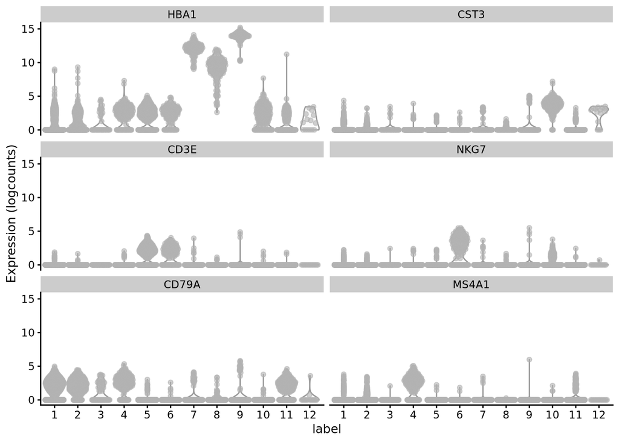

```r
known_genes <- c(
  "HBA1", # erythrocytes
  "CST3", # monocytes
  "CD3E", # T cells
  "NKG7", # NK T cells
  "CD79A",  # B cells
  "MS4A1" # CD20 B cells
  )

# violin plot
plotExpression(sce, x = "label", features = known_genes)
```